# U1-Predicting-response-times-of-the-Paris-Fire_Brigade-vehicles

Edgar Jullien, Antoine Settelen, Simon Weiss

2020-11-10

# Navigation

## 1. Introduction

### 1.0 Presentation of the project

This group project responds to **professor Nadine Galy instructions** written below :  
The project involves identifying a real-world business problem or opportunity and designing and implementing an analysis plan to address it using at least one of the modelling methods studied in the course. You are free to choose any business problem or opportunity or public policy issue that you consider challenging and useful to address using business analytics. The data that you use should be readily available and verifiable.

This is a notebook for the [Paris Fire Brigate](https://paris-fire-brigade.github.io/data-challenge/challenge.html) data challenge 2020 with [ENS](https://challengedata.ens.fr/participants/challenges/21/) and [College de France](https://www.college-de-france.fr/site/stephane-mallat/Challenges-2020.html).

**The goal of this playground challenge** is to predict the *The response times of the Paris Fire Brigade vehicles* which is the delay between: * the selection of a rescue vehicle (the time when a rescue team is warned) * and the rescue team arrival time at the scene of the request (information sent manually via portable radio)

This measurement is composed by the 2 following periods of time: * the activation period of the rescue team * the transit time of the rescue team

Based on features like trip coordinates, pickup date, type of the arrivall destination, vehicules etc..

The [data](https://challengedata.ens.fr/participants/challenges/21/) which covers the entier year 2018 for which inoperable data have been squeezed out comes in the shape of 219 337 training observations and 108 033 test observation. The dataset covers the entire year of 2018. Each row contains one Paris fire brigade intervention.

“Response time is one of the most important factors for firefighters because their ability to save lives and rescue people depends on it. Every fire department in the world seeks strategies to decrease their response time, and several analyses have been conducted in the past years to determine what could impact response time. In the meantime, fire departments have been collecting data on their interventions; yet, few of them actually use data science to develop a data-driven decision making approach.”https://medium.com/crim/predicting-the-response-times-of-firefighters-using-data-science-da79f6965f93

“A lot of fire departments and emergency services rely on geographic information systems tools, such as ESRI ARCGis or Network Analyst, to obtain estimations about the response time. These tools rely on computing the shortest route using a graphical representation of the road network, which usually gives an accurate estimate of the travel time. Their drawback is that they cannot always take into consideration external dynamic factors such as the weather, traffic or type of units or intervention. Hence, there is an opportunity for machine learning tools to be used here.”

**In this notebook**, we will first study and visualize the original data, engineer new features, and examine potential outliers. Then, we implement a boosted Tree for our first model, do some dimension reductions on qualitative features and implement a linear regression. Finaly, we created a final predict and uploaded it to the data plateforme.

We hope that this notebook will have good results to the challenge and responds fully to Nadine Galy requirement. As always, any feedback, questions, or constructive criticism are much appreciated.

### 1.0 Features description

**Input parameters (x_train.csv and x_test.csv):**

- **[ID]** `emergency vehicle selection`: identifier of the selection instance of an emergency vehicle for an intervention
- Intervention
  - `intervention`: identifier of the intervention
  - Alert reason
    - `alert reason category` (category): alert reason category
    - `alert reason` (category): alert reason
  - Address
    - `intervention on public roads` (boolean): 1 when it concerns an intervention on public roads, 0 otherwise
    - `floor` (int): floor of the intervention
    - `location of the event` (category): qualifies the location of the emergency request, for example: entrance hall, boiler room, motorway, etc.
    - `longitude intervention` (float): approximate longitude of the intervention address. **ATTENTION: `intervention_longitude`** !
    - `latitude intervention` (float): approximate latitude of the intervention address. **ATTENTION: `intervention_latitude`** !
  - Emergency vehicle
    - `emergency vehicle`: identifier of the emergency vehicle
      - `emergency vehicle type` (category): type of the emergency vehicle
      - `rescue center` (category): identifier of the rescue center to which belong the vehicle (parking spot of the emergency vehicle)
    - `selection time` (datetime): selection time of the emergency vehicle
      - `date key selection` (int): selection date in YYYYMMDD format
      - `time key selection` (int): selection time in HHMMSS format
    - State of the emergency vehicle preceding its selection for an intervention
      - Operational status of the vehicle preceding its selection
        - `status preceding selection` (category): status of the emergency vehicle prior to selection. An emergency vehicle is in various statuses during an intervention:
          - **Selection** - selection of the emergency vehicle by the rescue commitment application
          - **Departed** - the vehicle starts its route to the location of the emergency request
          - **Presented** - the vehicle arrives at the location of the request
          - **Hospital transportation** - the vehicle starts its transport of a victim to hospital
          - **Hospital arrival** - the vehicle arrives at the hospital
          - **Leaving hospital** - the vehicle leaves the hospital
          - **Returned** - the vehicle has returned to its parking spot
          - **Leave the premises** - because the vehicle can also simply leave the scene of an intervention without having to transport any victim
          - **Not available** - for various reasons the vehicle can be in an unavailable position
          - **Not relevant** - statutes without interest
        - `delta status preceding selection-selection` (int): number of seconds before the vehicle was selected when its previous status was entered
      - `departed from its rescue center` (boolean) : 1 when the vehicle departed from its rescue center (emergency vehicle parking spot), 0 otherwise
      - GPS position of the vehicle before departure
        - `longitude before departure` (float): longitude of the position of the vehicle preceding his departure. **ATTENTION: `departure_longitude`** !
        - `latitude previous departure` (float): latitude of the position of the vehicle preceding his departure. **ATTENTION: `departure_latitude`** !
        - `delta position gps previous departure-departure` (int): number of seconds before the selection of the vehicle where its GPS position was recorded (when not parked at its emergency center)
      - GPS tracks
        - `GPS tracks departure-presentation` (float pair list): successive GPS positions (*longitude,latitude;longitude,latitude,* etc.) of the vehicle between departure and presentation. This information is for informational purposes to study vehicle behaviors. (The beacons, emitting the GPS positions of vehicles, are currently not always lit)
        - `GPS tracks departure-presentation datetime` (datetime list): datetime associated with successive GPS positions between the departure and the presentation of the vehicle.
      - Estimated route
        - `OSRM estimated route` (json object): service route response of an OSRM instance (http://project-osrm.org/docs/v5.15.2/api/#route-service) setup with the Ile-de-France OpenStreetMap data
        - `OSRM estimated distance` (float): distance calculated by the OSRM route service
        - `OSRM estimated duration` (float): transit delay calculated by the OSRM route service

**Output parameters (y_train.csv and y_test.csv):**

- **[ID]** `emergency vehicle selection`: identifier of the selection instance of an emergency vehicle for an intervention
- **[TO PREDICT]** `delta selection-departure`(int): elapsed time in seconds between the selection and the departure of the emergency vehicle
- **[TO PREDICT]** `delta departure-presentation`(int): elapsed time in seconds between the departure of the emergency vehicle and its presentation on the intervention scene
- **[TO PREDICT]** `delta selection-presentation`(int): elapsed time in seconds between the selection of the emergency vehicle and its presentation on the intervention scene (delta selection-departure + delta departure-presentation)

**Supplementary files (x_train_additional_file.csv and x_test_additional_file.csv)**

- **[ID]** `emergency vehicle selection`: identifier of the selection instance of an emergency vehicle for an intervention
- `OSRM estimate from last observed GPS position`(json object): service route response from last observed GPS position of an OSRM instance (http://project-osrm.org/docs/v5.15.2/api/#route-service) setup with the Ile-de-France OpenStreetMap data
- `OSRM estimated distance from last observed GPS position`(float): distance (in meters) calculated by the OSRM route service from last observed GPS position
- `OSRM estimated distance from last observed GPS position`(float): distance (in meters) calculated by the OSRM route service from last observed GPS position
- `OSRM estimated duration from last observed GPS position`(float): transit delay (in seconds) calculated by the OSRM route service from last observed GPS position
- `time elapsed between selection and last observed GPS position` (float): in seconds
- `updated OSRM estimated duration` (float): time elapsed (in seconds) between selection and last observed GPS position + OSRM estimated duration from last observed GPS position

Good reading !

### 1.1 Load libraries

```r
library(magrittr)
library(data.table)
library(sandwich)
library(dplyr)
```

```r
library(ggplot2)
library(hms)
library(imputeTS)
library(leaflet)
library(Hmisc)
library(FactoMineR)
library(corrplot)
library(Matrix)
library(caret)
library(xgboost)
library(DataExplorer)
```

### 1.2 Load data, transform them into Datatable for better computation time and combine them.

```r
x_train <- read.csv("x_train.csv") %>% setDT
y_train <- read.csv("y_train.csv") %>% setDT
x_test <- read.csv("x_test.csv") %>% setDT
#View(x_train)
data <- cbind(x_train,y_train[,-1])#we don't keep id vehicule selection for no duplicate
#We rename a column which has a special caracter
c<- colnames(data)
c[14] <- "date.key.selection"
c[15] <- "time.key.selection"
colnames(data) <- c

#Same for x_test
c<- colnames(x_test)
c[14] <- "date.key.selection"
c[15] <- "time.key.selection"
colnames(x_test) <- c
```

### 1.3 File structure and content

Let’s have an overview of the data sets using the *introduce* and *head* tools. First the training data:

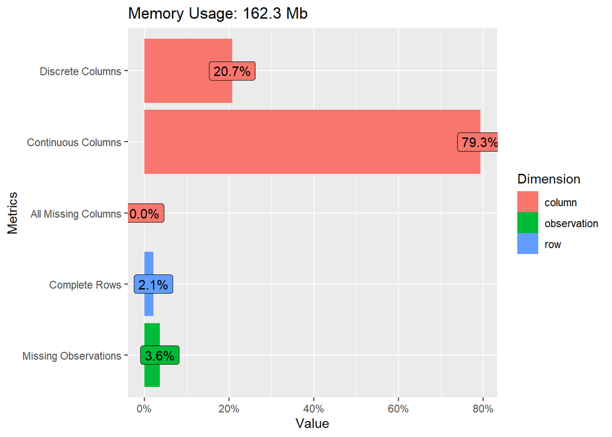

```r
plot_intro(data)
```

```r
glimpse(data)
```

```
## Rows: 219,337
## Columns: 29
## $ emergency.vehicle.selection                     <int> 5105452, 4720915, 5...
## $ intervention                                    <int> 13264186, 12663715,...
## $ alert.reason.category                           <int> 3, 3, 3, 3, 3, 3, 9...
## $ alert.reason                                    <int> 2162, 2124, 2163, 2...
## $ intervention.on.public.roads                    <int> 0, 0, 0, 0, 0, 0, 0...
## $ floor                                           <int> 0, 1, 2, 0, 3, 1, 4...
## $ location.of.the.event                           <dbl> 148, 136, 139, 136,...
## $ longitude.intervention                          <dbl> 2.284796, 2.247464,...
## $ latitude.intervention                           <dbl> 48.87967, 48.81819,...
## $ emergency.vehicle                               <int> 4511, 4327, 4509, 5...
## $ emergency.vehicle.type                          <chr> "VSAV BSPP", "PSE",...
## $ rescue.center                                   <int> 2447, 2464, 2438, 2...
## $ selection.time                                  <chr> "2018-07-08 19:02:4...
```

[output cut: 16 more lines]

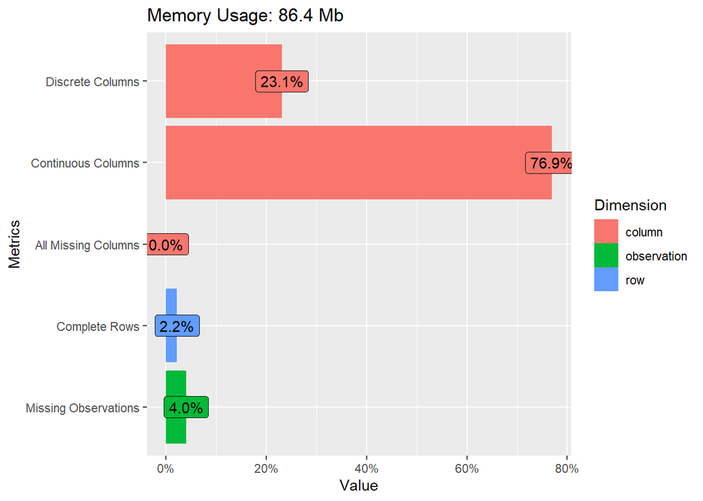

```r
plot_intro(x_test)
```

```r
glimpse(x_test)
```

```
## Rows: 108,033
## Columns: 26
## $ emergency.vehicle.selection                     <int> 5271704, 5092931, 5...
## $ intervention                                    <int> 13535032, 13244794,...
## $ alert.reason.category                           <int> 3, 3, 3, 3, 3, 3, 1...
## $ alert.reason                                    <int> 2113, 2113, 2112, 2...
## $ intervention.on.public.roads                    <int> 0, 0, 1, 0, 1, 0, 0...
## $ floor                                           <int> 2, 0, 0, 0, 0, 15, ...
## $ location.of.the.event                           <dbl> 136, 228, 148, 201,...
## $ longitude.intervention                          <dbl> 2.464084, 2.325948,...
## $ latitude.intervention                           <dbl> 48.81844, 48.92520,...
## $ emergency.vehicle                               <int> 5755, 3100, 3538, 6...
## $ emergency.vehicle.type                          <chr> "VSAV BSPP", "VSAV ...
## $ rescue.center                                   <int> 2483, 2462, 2482, 2...
## $ selection.time                                  <chr> "2018-10-02 12:41:2...
## $ date.key.selection                              <int> 20181002, 20180703,...
## $ time.key.selection                              <int> 124122, 131447, 134...
## $ status.preceding.selection                      <chr> "RentrÃ©", "RentrÃ©...
## $ delta.status.preceding.selection.selection      <int> 953, 1906, 654, 108...
## $ departed.from.its.rescue.center                 <int> 1, 1, 1, 1, 1, 1, 1...
## $ longitude.before.departure                      <dbl> 2.481148, 2.301399,...
## $ latitude.before.departure                       <dbl> 48.84103, 48.92930,...
## $ delta.position.gps.previous.departure.departure <dbl> NA, NA, NA, NA, NA,...
## $ GPS.tracks.departure.presentation               <chr> "", "2.309139,48.92...
## $ GPS.tracks.datetime.departure.presentation      <chr> "", "2018-07-03 13:...
## $ OSRM.response                                   <chr> "{\"code\":\"Ok\",\...
## $ OSRM.estimated.distance                         <dbl> 3266.8, 2710.3, 914...
## $ OSRM.estimated.duration                         <dbl> 336.5, 218.4, 85.1,...
```

We find : - We have a great mix of qualitative data and quantitative data - Some quali data are characters such as "status.preceding.selection, other dummy variables coded 0,1 such as $intervention.on.public.roads - We have NA values - We have ID variables that we can remove - We will have to deal with outliers

### 1.4 Missing values

```r
# visualize missing data
introduce(data)
```

```
##      rows columns discrete_columns continuous_columns all_missing_columns
## 1: 219337      29                6                 23                   0
##    total_missing_values complete_rows total_observations memory_usage
## 1:               227148          4553            6360773    170165312
```

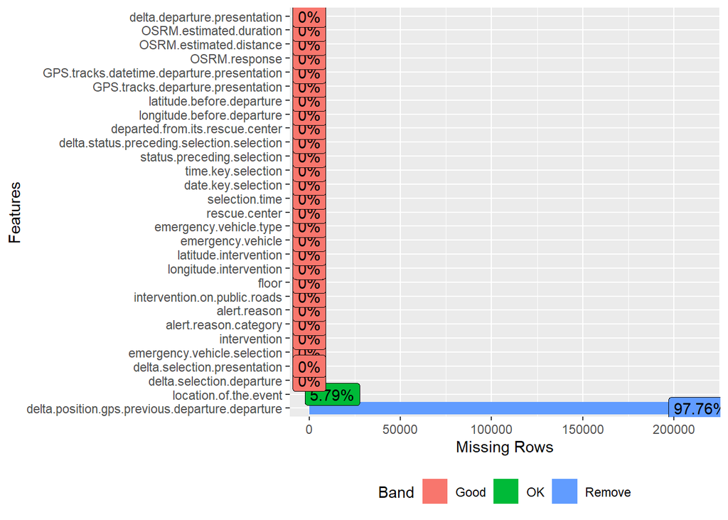

```r
plot_missing(data)
```

```r
introduce(x_train)
```

```
##      rows columns discrete_columns continuous_columns all_missing_columns
## 1: 219337      26                6                 20                   0
##    total_missing_values complete_rows total_observations memory_usage
## 1:               227144          4553            5702762    164900528
```

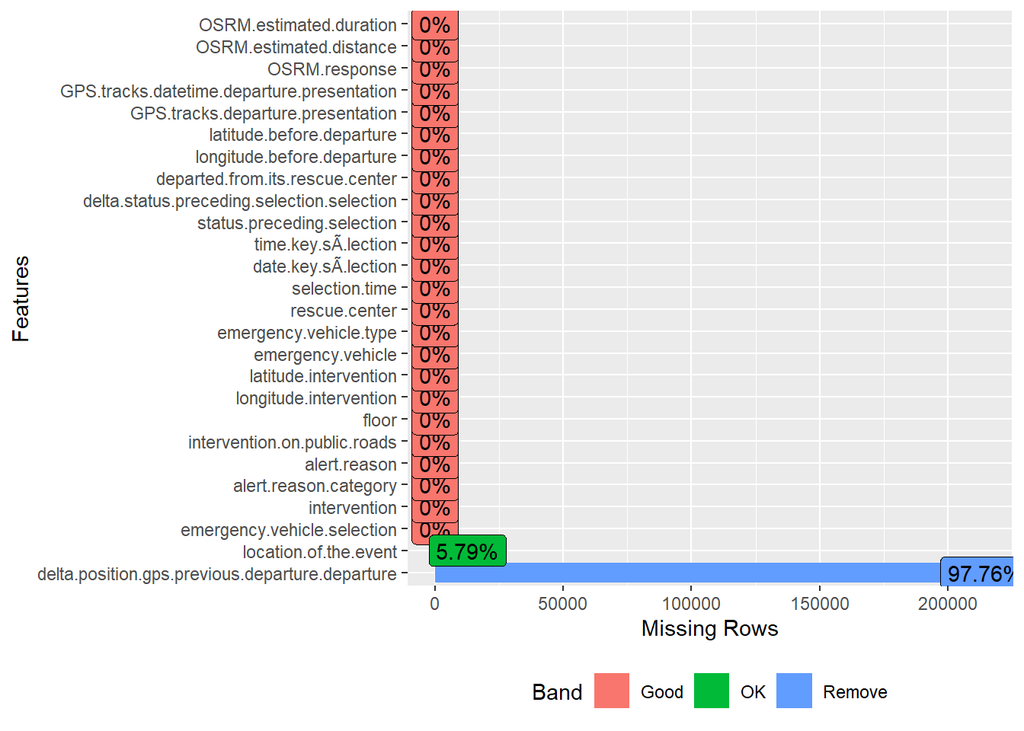

```r
plot_missing(x_train)
```

We remoev the useless column and the raw with empty cells

```r
data <- data[,-24] # delete the column OSMR response json object
data <- data[,-21] #delete the column delta position gps
```

Same with x_test data

```r
x_test<-x_test[,-24]
x_test<-x_test[,-21]
```

Let’s check how many na it remains

```r
sum(is.na(data))
```

```
## [1] 12714
```

```r
sum(is.na(x_test))
```

```
## [1] 6331
```

Good proporition (around 5% of dataset), acceptable to omit those values.

```r
data <- na.omit(data)

which(is.na(data))
```

```
## integer(0)
```

(We apply same cleaning in x_train and y_train in case)

```r
y_train <- na.omit(y_train)
x_train<-na.omit(x_train)
```

### 1.5 Convertion into right format

Convert qualitative variables into factor

```r
data$alert.reason.category<- as.factor(data$alert.reason.category)
data$alert.reason<-as.factor(data$alert.reason)
data$location.of.the.event <- as.factor(data$location.of.the.event)
data$intervention.on.public.roads <- as.factor(data$intervention.on.public.roads)
data$emergency.vehicle.type <- as.factor(data$emergency.vehicle.type)
data$rescue.center <- as.factor(data$rescue.center)
data$status.preceding.selection  <- as.factor(data$status.preceding.selection)
data$departed.from.its.rescue.center  <- as.factor(data$departed.from.its.rescue.center)
data$floor<-as.factor(data$floor)
data$emergency.vehicle<-as.factor(data$emergency.vehicle)
```

Apply same in x_test

```r
x_test$alert.reason.category<- as.factor(x_test$alert.reason.category)
x_test$alert.reason<-as.factor(x_test$alert.reason)
x_test$location.of.the.event <- as.factor(x_test$location.of.the.event)
x_test$intervention.on.public.roads <- as.factor(x_test$intervention.on.public.roads )
x_test$emergency.vehicle.type <- as.factor(x_test$emergency.vehicle.type)
x_test$rescue.center <- as.factor(x_test$rescue.center)
x_test$status.preceding.selection  <- as.factor(x_test$status.preceding.selection)
x_test$departed.from.its.rescue.center  <- as.factor(x_test$departed.from.its.rescue.center)
x_test$floor<-as.factor(x_test$floor)
x_test$emergency.vehicle<-as.factor(x_test$emergency.vehicle)
```

Manage *Selection time

- `selection time` (datetime): selection time of the emergency vehicle * `date key selection` (int): selection date in YYYYMMDD format * `time key selection` (int): selection time in HHMMSS format

We can delete selection time. We keep numeric format for date key selection and time key selection for now (more manageable for cor analysis and regression). For EDA part, we could convert them into date and time format

```r
data<-data[,-c("selection.time")]
x_test<-x_test[,-c("selection.time")]
```

Store quali, quali and quali with Ys variables

```r
str(data)
```

```
## Classes 'data.table' and 'data.frame':   206625 obs. of  26 variables:
##  $ emergency.vehicle.selection               : int  5105452 4720915 5365374 4741586 5381209 4731603 5196431 4774057 5277444 5277017 ...
##  $ intervention                              : int  13264186 12663715 13675521 12695745 13698743 12680636 13415648 12744692 13544161 13543445 ...
##  $ alert.reason.category                     : Factor w/ 9 levels "1","2","3","4",..: 3 3 3 3 3 3 9 3 3 3 ...
##  $ alert.reason                              : Factor w/ 122 levels "1911","1912",..: 60 41 61 60 60 31 101 60 32 31 ...
##  $ intervention.on.public.roads              : Factor w/ 2 levels "0","1": 1 1 1 1 1 1 1 1 2 1 ...
##  $ floor                                     : Factor w/ 45 levels "-10","-6","-5",..: 8 9 10 8 11 9 12 8 8 8 ...
##  $ location.of.the.event                     : Factor w/ 210 levels "100","101","102",..: 48 36 39 36 5 56 36 36 48 94 ...
##  $ longitude.intervention                    : num  2.28 2.25 2.26 2.39 2.46 ...
##  $ latitude.intervention                     : num  48.9 48.8 48.8 48.8 48.9 ...
##  $ emergency.vehicle                         : Factor w/ 639 levels "1815","1823",..: 398 334 396 517 473 330 293 575 398 606 ...
##  $ emergency.vehicle.type                    : Factor w/ 41 levels "AR","BEAA BSPP",..: 37 24 37 37 37 37 24 37 37 37 ...
##  $ rescue.center                             : Factor w/ 79 levels "2418","2434",..: 15 30 6 72 42 55 42 16 15 50 ...
##  $ date.key.selection                        : int  20180708 20180104 20181116 20180115 20181124 20180109 20180824 20180130 20181005 20181004 ...
##  $ time.key.selection                        : int  190243 90259 101147 3846 3426 222327 81800 74243 82648 5918 ...
##  $ status.preceding.selection                : Factor w/ 2 levels "Disponible","RentrÃ©": 2 2 1 2 2 2 2 2 2 2 ...
##  $ delta.status.preceding.selection.selection: int  2027 28233 1981 1842 2716 5592 37282 5661 31361 304 ...
##  $ departed.from.its.rescue.center           : Factor w/ 2 levels "0","1": 2 2 1 2 2 2 2 2 2 2 ...
##  $ longitude.before.departure                : num  2.29 2.27 2.27 2.39 2.44 ...
##  $ latitude.before.departure                 : num  48.9 48.8 48.9 48.8 48.9 ...
##  $ GPS.tracks.departure.presentation         : chr  "2.289000,48.885113;2.288861,48.884998;2.288000,48.883335;2.284444,48.878582;2.286250,48.880196" "" "2.272972,48.850498;2.269056,48.847443;2.262611,48.839554;2.260306,48.836887;2.257917,48.836250" "2.394278,48.782112;2.393639,48.776833" ...
##  $ GPS.tracks.datetime.departure.presentation: chr  "2018-07-08 19:04:43;2018-07-08 19:05:55;2018-07-08 19:07:07;2018-07-08 19:08:19;2018-07-08 19:09:18" "" "2018-11-16 10:14:31;2018-11-16 10:15:43;2018-11-16 10:16:57;2018-11-16 10:18:07;2018-11-16 10:19:19" "2018-01-15 00:42:46;2018-01-15 00:43:…
##  $ OSRM.estimated.distance                   : num  952 2238 3026 1934 2707 ...
##  $ OSRM.estimated.duration                   : num  106 243 295 167 263 ...
##  $ delta.selection.departure                 : num  377 402 345 575 409 447 597 414 356 408 ...
##  $ delta.departure.presentation              : num  123 144 118 185 131 119 171 136 114 120 ...
##  $ delta.selection.presentation              : num  253 257 226 390 277 327 425 278 241 287 ...
##  - attr(*, ".internal.selfref")=<externalptr>
```

```r
colnames(data)
```

```
##  [1] "emergency.vehicle.selection"
##  [2] "intervention"
##  [3] "alert.reason.category"
##  [4] "alert.reason"
##  [5] "intervention.on.public.roads"
##  [6] "floor"
##  [7] "location.of.the.event"
##  [8] "longitude.intervention"
##  [9] "latitude.intervention"
## [10] "emergency.vehicle"
## [11] "emergency.vehicle.type"
## [12] "rescue.center"
## [13] "date.key.selection"
## [14] "time.key.selection"
## [15] "status.preceding.selection"
## [16] "delta.status.preceding.selection.selection"
## [17] "departed.from.its.rescue.center"
## [18] "longitude.before.departure"
## [19] "latitude.before.departure"
## [20] "GPS.tracks.departure.presentation"
## [21] "GPS.tracks.datetime.departure.presentation"
## [22] "OSRM.estimated.distance"
## [23] "OSRM.estimated.duration"
## [24] "delta.selection.departure"
## [25] "delta.departure.presentation"
## [26] "delta.selection.presentation"
```

```r
data.quali<-data[,c(3,4,5,6,7,10,11,12,15,17)]


data.quanti.y<-data[,-c(3,4,5,6,7,10,11,12,15,17)] #with Ys

data.quanti<-data[,-c(3,4,5,6,7,10,11,12,15,17,24,25,26)]
```

## 2. EDA

### 2.1 Intro : map

We start with a map of Paris and overlay a manageable number of coordinates to get a general overview of the locations and distances in question. For this visualization we use the [leaflet](https://rstudio.github.io/leaflet/) package, which includes a variety of nice tools for interactive maps. In this map you can zoom and pan through the intervention locations:

```r
set.seed(1234)
foo <- sample_n(data, 8e3)

leaflet(data = foo) %>% addProviderTiles("Esri.NatGeoWorldMap") %>%
  addCircleMarkers(~ longitude.intervention, ~latitude.intervention, radius = 1,
                   color = "blue", fillOpacity = 0.3)
```

[interactive chart not shown]

Fig. 1

### 2.2 Dependant Variables Ys

We have 2 dependant variables and 1 global variable

```r
summary(y_train[,-1])
```

```
##  delta.selection.departure delta.departure.presentation
##  Min.   : 207.0            Min.   :103.0
##  1st Qu.: 410.0            1st Qu.:120.0
##  Median : 474.0            Median :128.0
##  Mean   : 491.2            Mean   :138.1
##  3rd Qu.: 549.0            3rd Qu.:149.0
##  Max.   :2177.0            Max.   :347.0
##  delta.selection.presentation
##  Min.   :  93.0
##  1st Qu.: 277.0
##  Median : 334.0
##  Mean   : 352.6
##  3rd Qu.: 406.0
##  Max.   :2015.0
```

Plot density distribution for time of vehicle selection

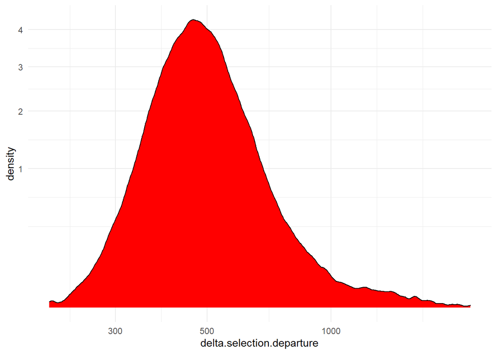

```r
data %>%
  ggplot(aes(delta.selection.departure)) +
  geom_density(fill = "red", bins = 100) +
  scale_x_log10() +
  scale_y_sqrt() +
  theme_minimal()
```

Note the logarithmic x-axis and square-root y-axis.

Plot density distribution the time to present to the place

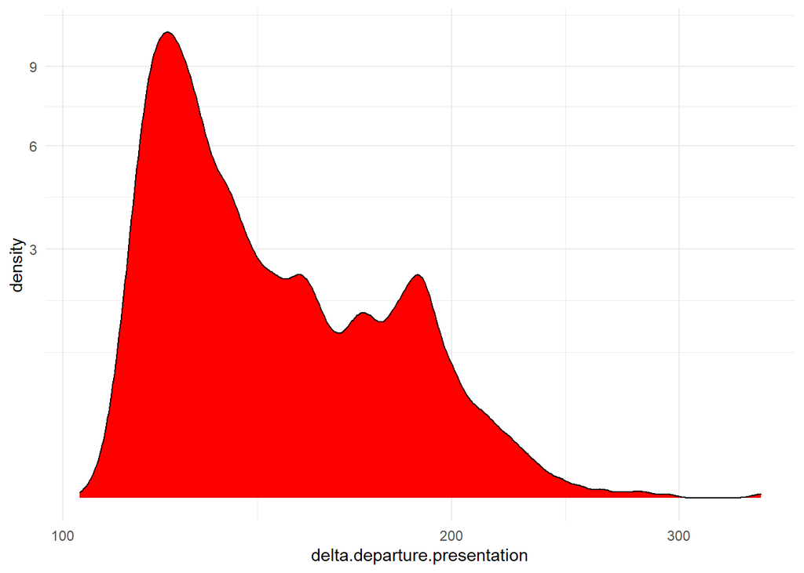

```r
data %>%
  ggplot(aes(delta.departure.presentation)) +
  geom_density(fill = "red", bins = 100) +
  scale_x_log10() +
  scale_y_sqrt() +
  theme_minimal()
```

Box plots Ys

For delta.selection.departure

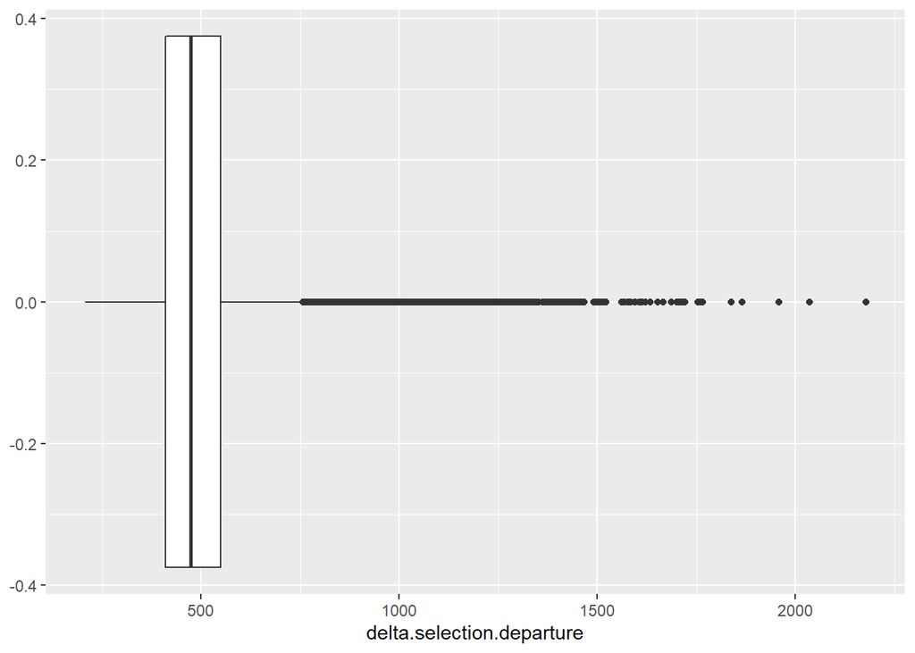

```r
data %>%
  ggplot(aes(delta.selection.departure)) +
  geom_boxplot()
```

For delta.departure. presentation

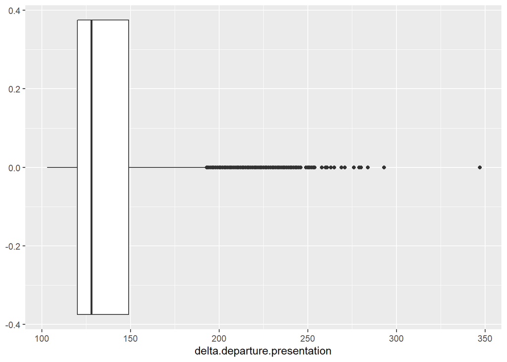

```r
data %>%
  ggplot(aes(delta.departure.presentation)) +
  geom_boxplot()
```

Cor between Ys

```r
corr<-rcorr(as.matrix(y_train[,-c(1,4)])) # We remove global and ID which will be cor
y_train_cor= corr$r

corr
```

```
##                              delta.selection.departure
## delta.selection.departure                         1.00
## delta.departure.presentation                      0.36
##                              delta.departure.presentation
## delta.selection.departure                            0.36
## delta.departure.presentation                         1.00
##
## n= 108032
##
##
## P
##                              delta.selection.departure
## delta.selection.departure
## delta.departure.presentation  0
##                              delta.departure.presentation
## delta.selection.departure     0
## delta.departure.presentation
```

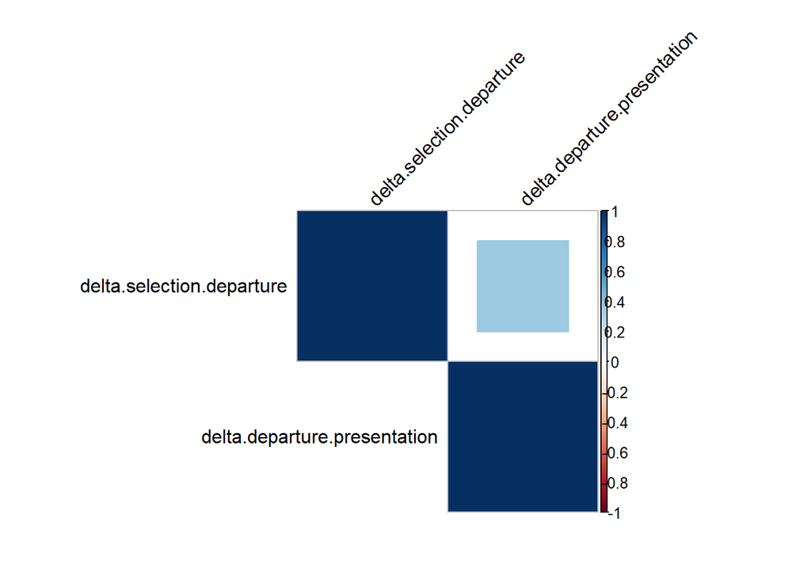

```r
corrplot(y_train_cor, method="square",type="upper", order="hclust", tl.col="black", tl.srt=45)
```

#### 2.2.1 Manage outliers for Ys values

Plot delta.selection.departure

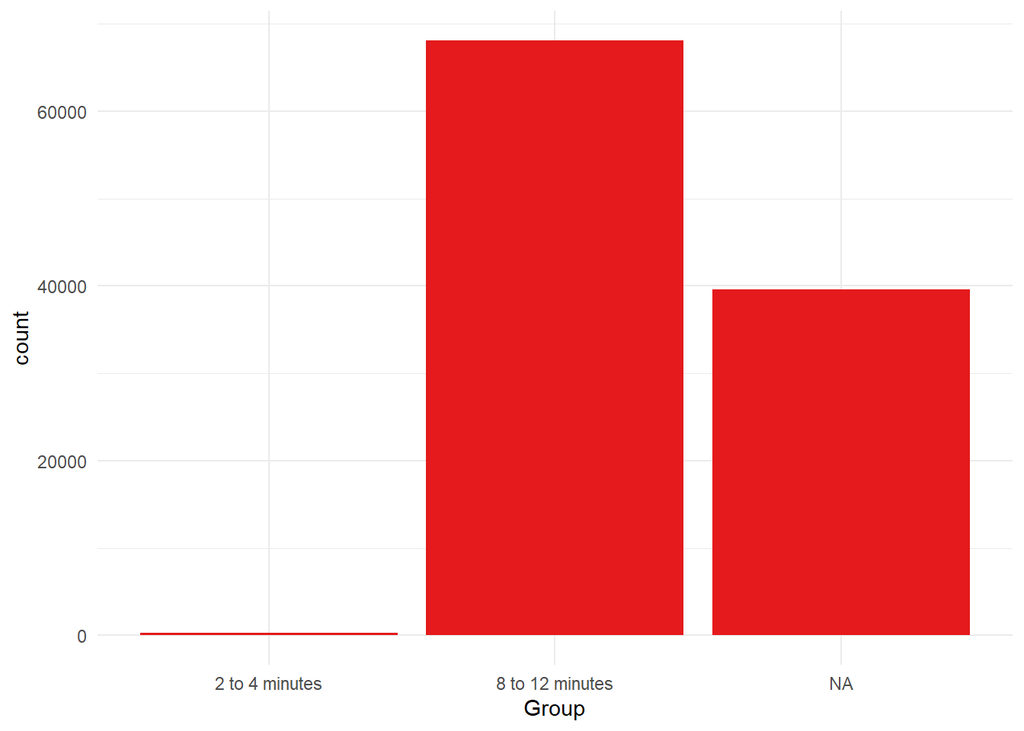

```r
y_train %>%
  mutate(
      delta.selection.departure_minutes = round(delta.selection.departure / 60, 0),
    duration_grp = case_when(
      between(delta.selection.departure_minutes, 0,  2)  ~ "Less than 2 minutes",
      between(delta.selection.departure_minutes, 2, 4) ~ "2 to 4 minutes",
      between(delta.selection.departure_minutes, 4, 8) ~ "8 to 12 minutes",
      delta.selection.departure_minutes >= 8 ~ "8 or more minutes"
    ),
    duration_grp = factor(duration_grp,
                          levels = c("Less than 2 minutes", "2 to 4 minutes", "8 to 12 minutes", "12 or more minutes"))
  ) %>%
  group_by(duration_grp) %>%
  ggplot(aes(x=duration_grp,group=duration_grp)) +
  geom_bar(fill="#E41A1C") +
  labs(x="Group", y="count") +
  theme_minimal()
```

Departure to presentation

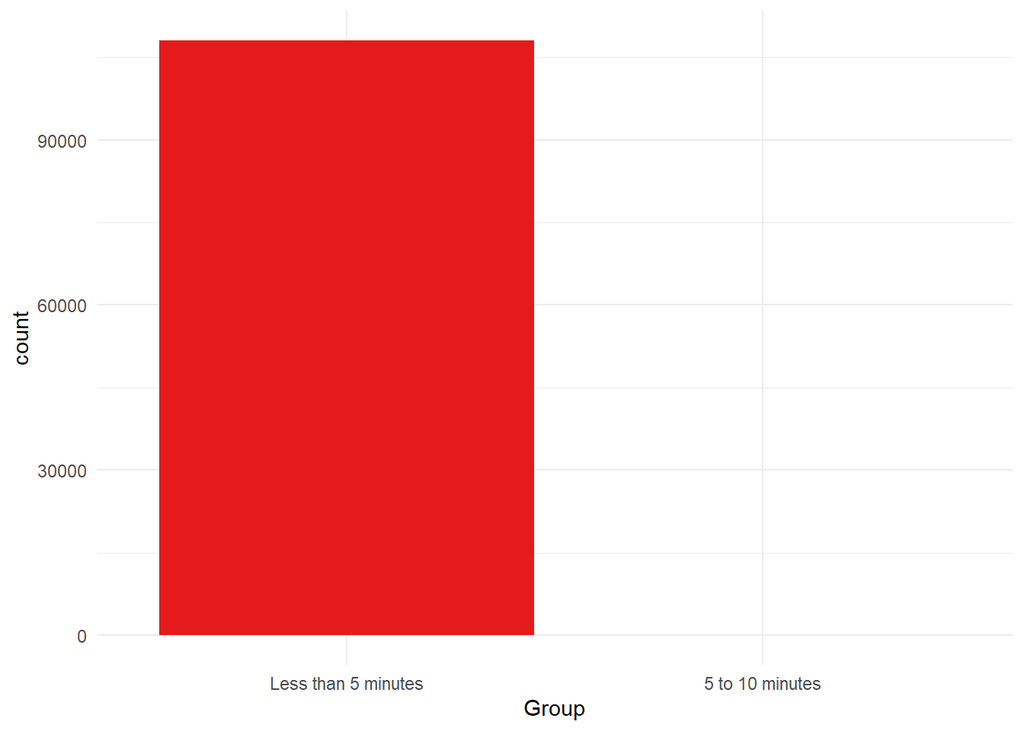

```r
y_train %>%
  mutate(
      delta.departure.presentation_minutes = round(delta.departure.presentation / 60, 0),
    duration2_grp = case_when(
      between(delta.departure.presentation_minutes, 0,  5)  ~ "Less than 5 minutes",
      between(delta.departure.presentation_minutes, 5, 10) ~ "5 to 10 minutes",
      between(delta.departure.presentation_minutes, 10, 15) ~ "10 to 15 minutes",
      between(delta.departure.presentation_minutes, 15, 20) ~ "15 to 20 minutes",
      delta.departure.presentation_minutes >= 20 ~ " 20 or more minutes"
    ),
    duration2_grp = factor(duration2_grp,
                          levels = c("Less than 5 minutes", "5 to 10 minutes", "10 to 15 minutes", "15 to 20 minutes","20 or more minutes" ))
  ) %>%
  group_by(duration2_grp) %>%
  ggplot(aes(x=duration2_grp,group=duration2_grp)) +
  geom_bar(fill="#E41A1C") +
  labs(x="Group", y="count") +
  theme_minimal()
```

Max 20 min

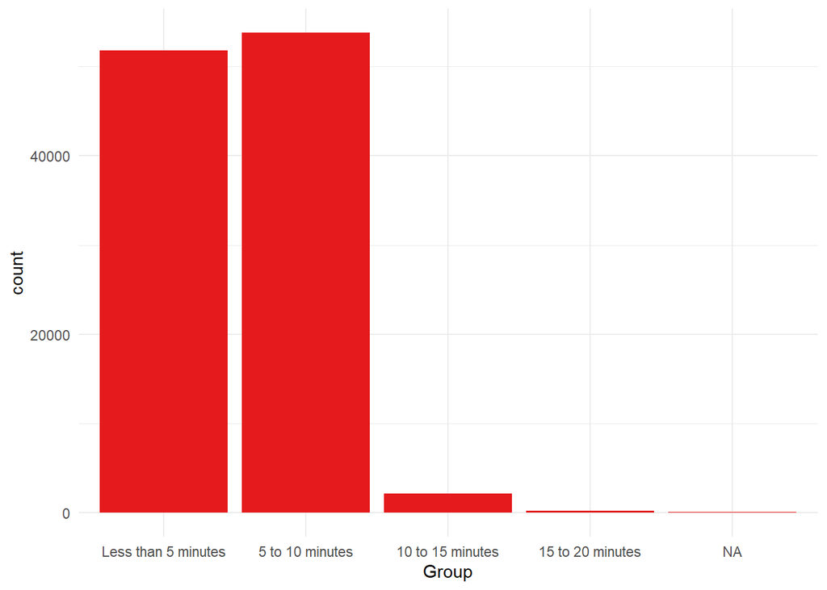

```r
y_train %>%
  mutate(
      delta.selection.presentation_minutes = round(delta.selection.presentation / 60, 0),
    duration3_grp = case_when(
      between(delta.selection.presentation_minutes, 0,  5)  ~ "Less than 5 minutes",
      between(delta.selection.presentation_minutes, 5, 10) ~ "5 to 10 minutes",
      between(delta.selection.presentation_minutes, 10, 15) ~ "10 to 15 minutes",
      between(delta.selection.presentation_minutes, 15, 20) ~ "15 to 20 minutes",
      delta.selection.presentation_minutes >= 20 ~ " 20 or more minutes"
    ),
    duration3_grp = factor(duration3_grp,
                          levels = c("Less than 5 minutes", "5 to 10 minutes", "10 to 15 minutes", "15 to 20 minutes","20 or more minutes" ))
  ) %>%
  group_by(duration3_grp) %>%
  ggplot(aes(x=duration3_grp,group=duration3_grp)) +
  geom_bar(fill="#E41A1C") +
  labs(x="Group", y="count") +
  theme_minimal()
```

=> Most of duration are between 0 to 20 min (1200 sec) We can set our outlier cleaning

```r
data<- data[data$delta.selection.departure < 1200,]
data<-data[data$delta.departure.presentation < 1200,]
data<-data[data$delta.selection.presentation < 1200,]
```

#### 2.2.2 Relation analysis between Y and other variables

In this part, we will first try to check if there is relation between our dependent variables and the dependent

Let’s study Y0 ‘selection-departure’, Y1’departure-presentation’,Y2’selection-presentation’ vs feature vars

data and y without GPS data

```r
data.nogps<-data[,-c(21,20)]
```

We sample data in 3000 observations for scatter plot

```r
set.seed(1234)
foocor.all <- sample_n(data.nogps, 3000)
```

Let’s use here scatter plot. Scatter plot are plotted along two axes, the pattern of the resulting points revealing any correlation present. One pattern of special interest is a linear pattern, where the data has a general look of a line going uphill or downhill.

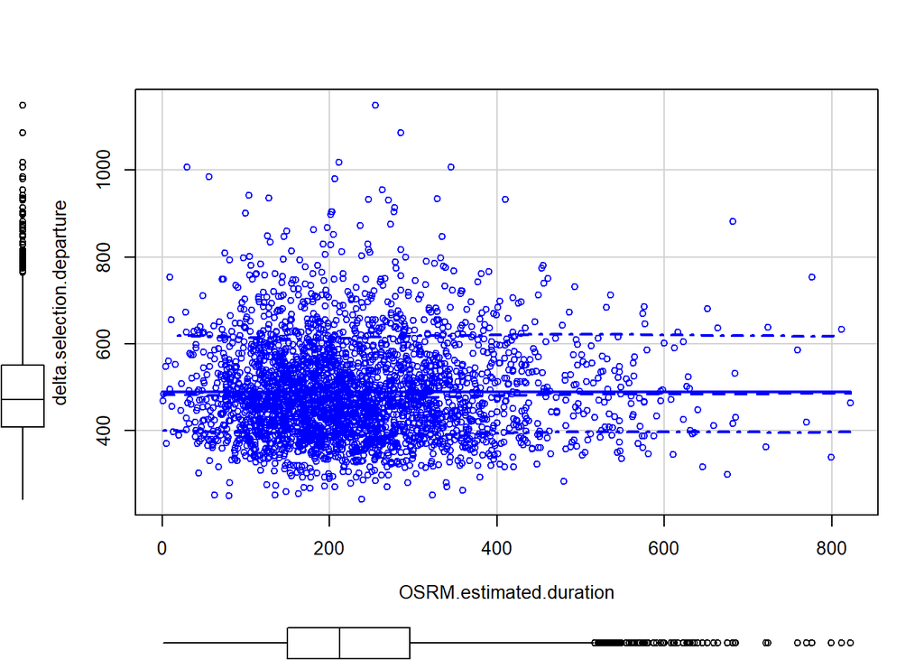

```r
car::scatterplot(delta.selection.departure ~ OSRM.estimated.duration, data = foocor.all,
                 smoother = TRUE, grid = TRUE)
```

Here we can see that there no clear linear correlation, maybe a some little smooth trend. But let’s take delta. departure. presentation vs the OSRM estimated duration.

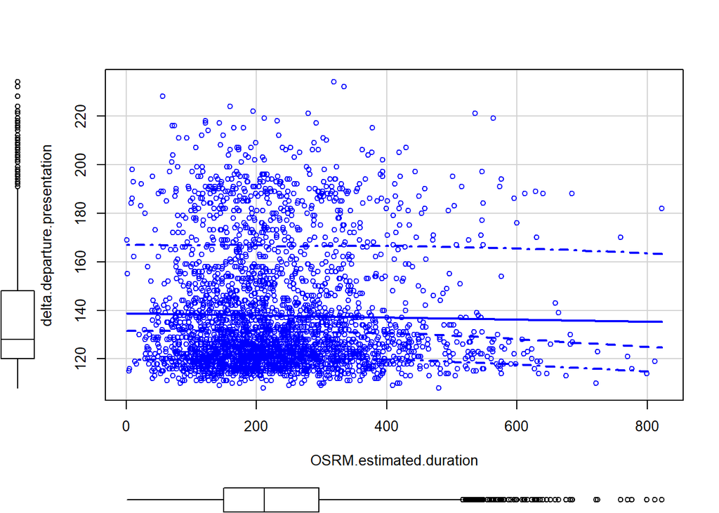

```r
car::scatterplot(delta.departure.presentation~ OSRM.estimated.duration, data = foocor.all,
                 smoother = TRUE, grid = TRUE)
```

Let’s scatter plot matrix. We just check the first lines for **ys vs other variables** for now and try to identify visually if there is some high independent explicative variable.

Let’s start by Y0 ‘selection-departure’

Plot 5 first

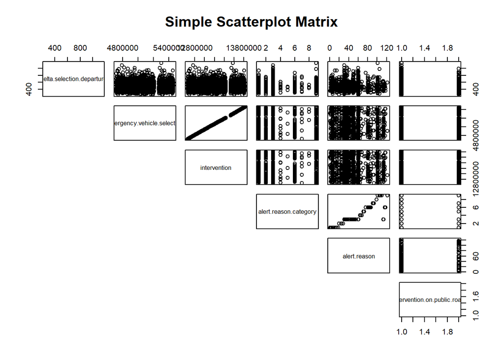

```r
pairs(delta.selection.departure~.,data=foocor.all[,c(1,2,3,4,5,22)],
   main="Simple Scatterplot Matrix",lower.panel = NULL)
```

It seems that we don’t have clear linear correlation. Let’s scatter plot the 5 next features.

5 next

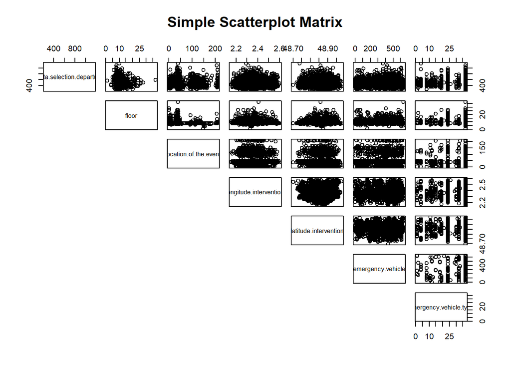

```r
pairs(delta.selection.departure~.,data=foocor.all[,c(6,7,8,9,10,11,22)],
   main="Simple Scatterplot Matrix",lower.panel = NULL)
```

Same conclusion.

5 next

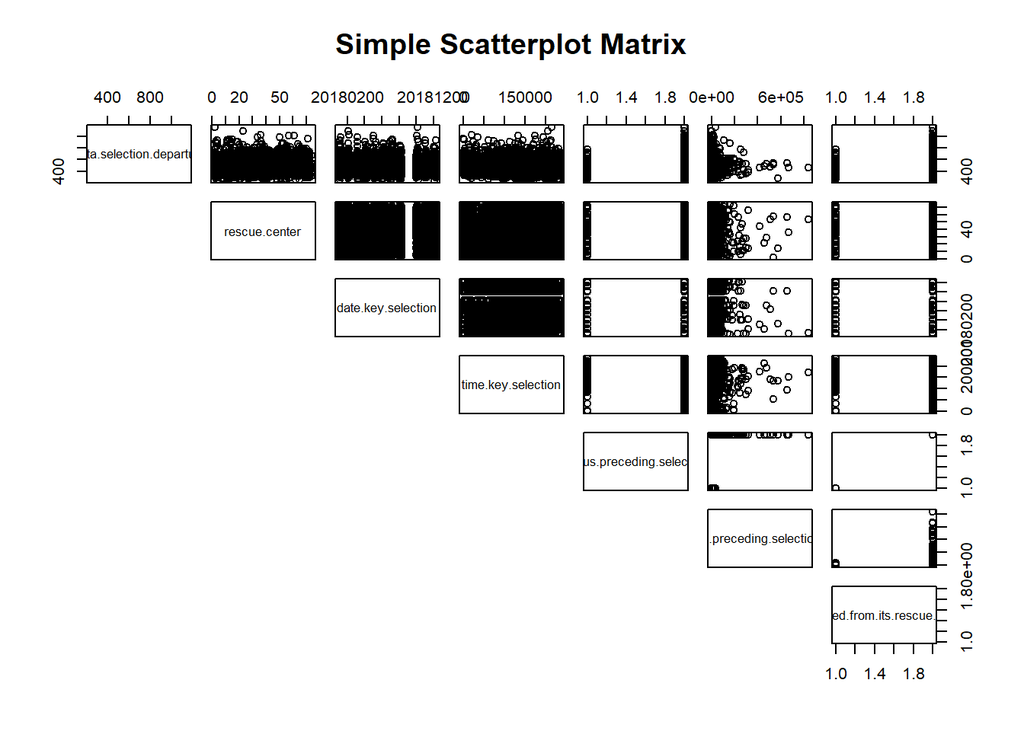

```r
pairs(delta.selection.departure~.,data=foocor.all[,c(12,13,14,15,16,17,22)],
   main="Simple Scatterplot Matrix",lower.panel = NULL)
```

Same conclusion.

5 next

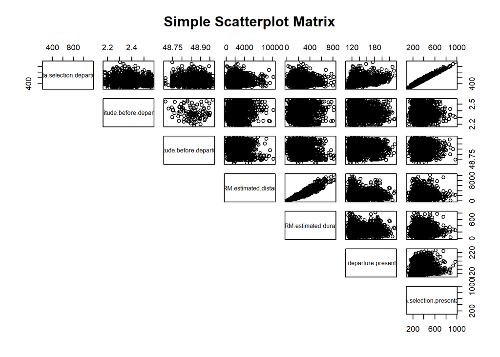

```r
pairs(delta.selection.departure~.,data=foocor.all[,c(18,19,20,21,22,23,24)],
   main="Simple Scatterplot Matrix",lower.panel = NULL)
```

We will deeper our correlation analysis in the 4. part.

Let’s quickly check scatter plot matrix for delta.departure.presentation.

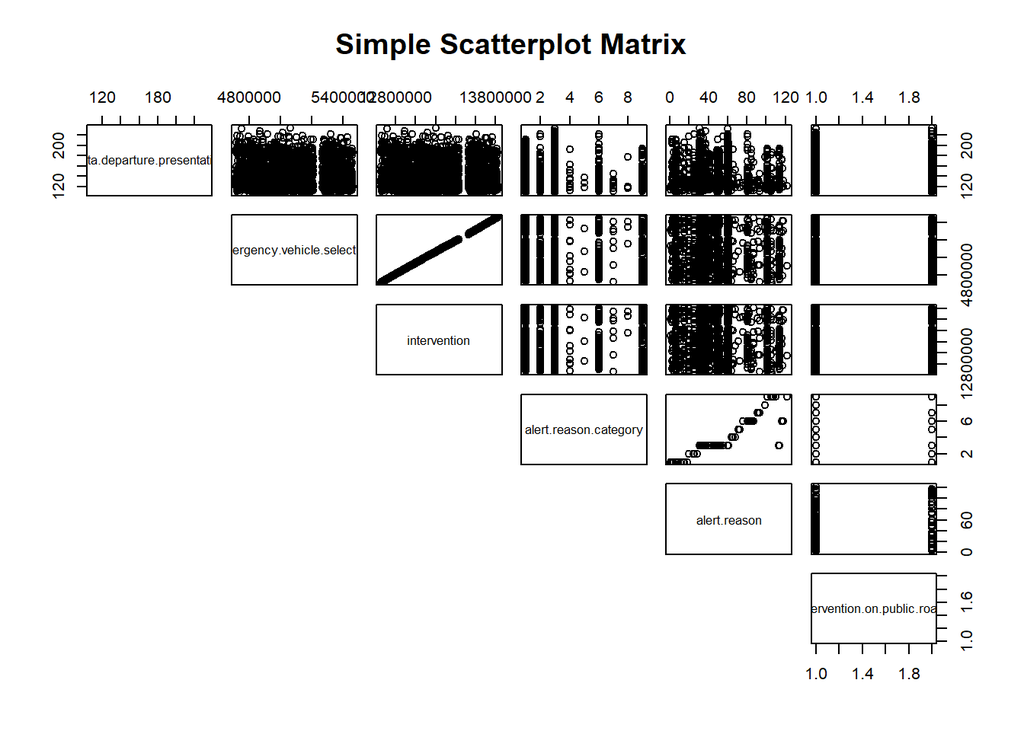

```r
pairs(delta.departure.presentation~.,data=foocor.all[,c(1,2,3,4,5,23)],
   main="Simple Scatterplot Matrix",lower.panel = NULL)
```

Same conclusion.

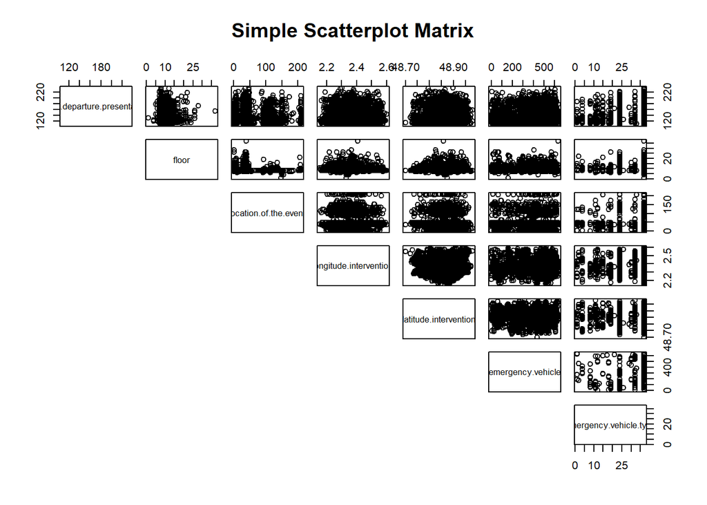

```r
pairs(delta.departure.presentation~.,data=foocor.all[,c(6,7,8,9,10,11,23)],
   main="Simple Scatterplot Matrix",lower.panel = NULL)
```

Same conclusion

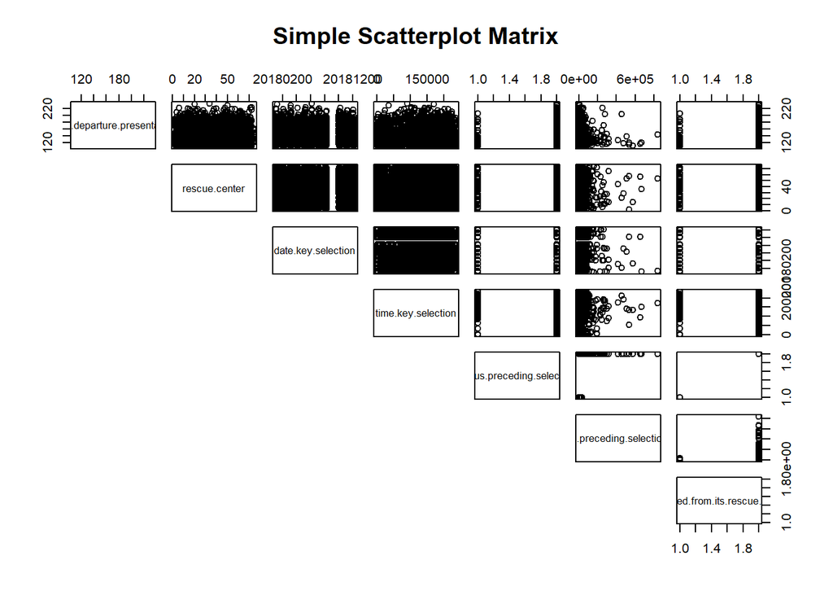

```r
pairs(delta.departure.presentation~.,data=foocor.all[,c(12,13,14,15,16,17,23)],
   main="Simple Scatterplot Matrix",lower.panel = NULL)
```

Same conclusion.

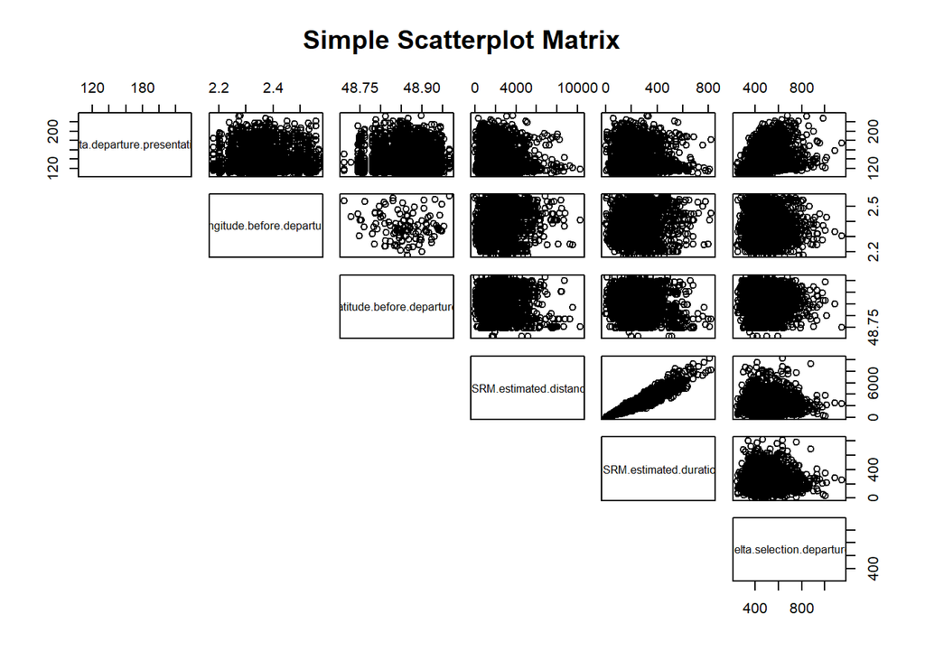

```r
pairs(delta.departure.presentation~.,data=foocor.all[,c(18,19,20,21,22,23)],
   main="Simple Scatterplot Matrix",lower.panel = NULL)
```

We will deeper our correlation analysis in the 4part of EDA.

But first, let’s manage outliers with some EDA with independant variables !

## 3. Explanatory data : Manage Outliers

### 3.1 Verify data outliers

#### 3.1.1 Quantitative Variables

##### 3.1.1.1 Histograms

```r
which(is.na(data.quanti)) #check for NA values before starting
```

```
## integer(0)
```

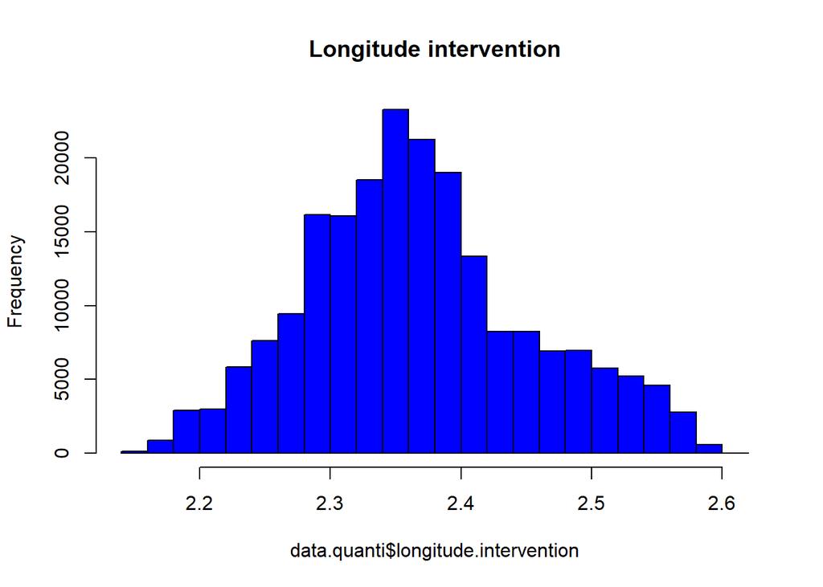

```r
hist(data.quanti$longitude.intervention, col="blue",main="Longitude intervention")
```

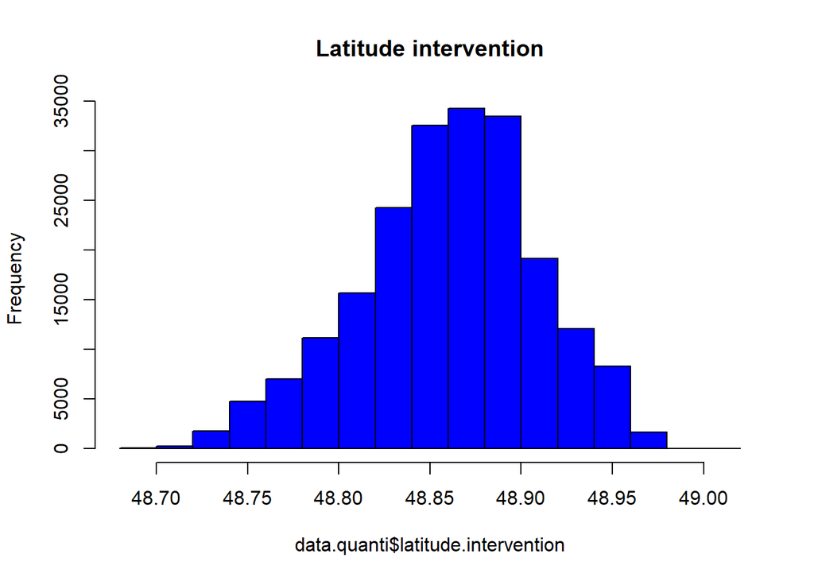

```r
hist(data.quanti$latitude.intervention, col="blue",main="Latitude intervention")
```

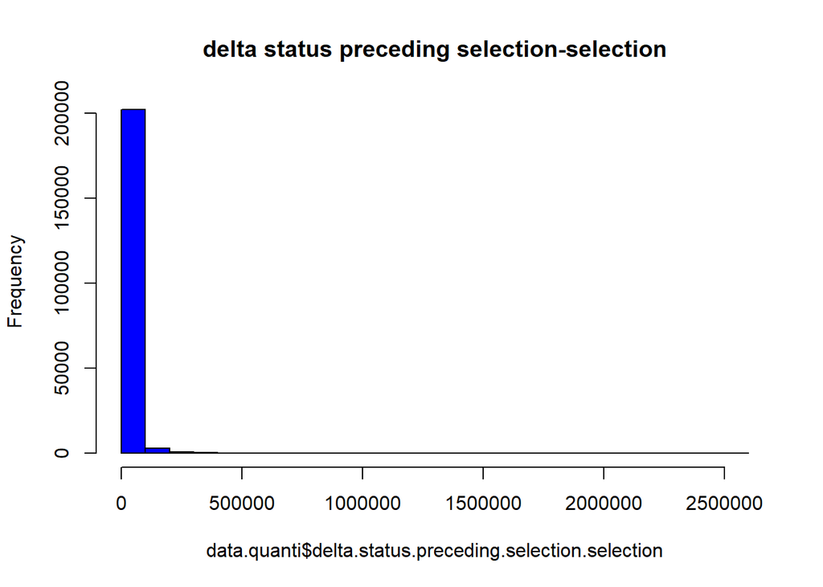

```r
hist(data.quanti$delta.status.preceding.selection.selection, col="blue",main="delta status preceding selection-selection")
```

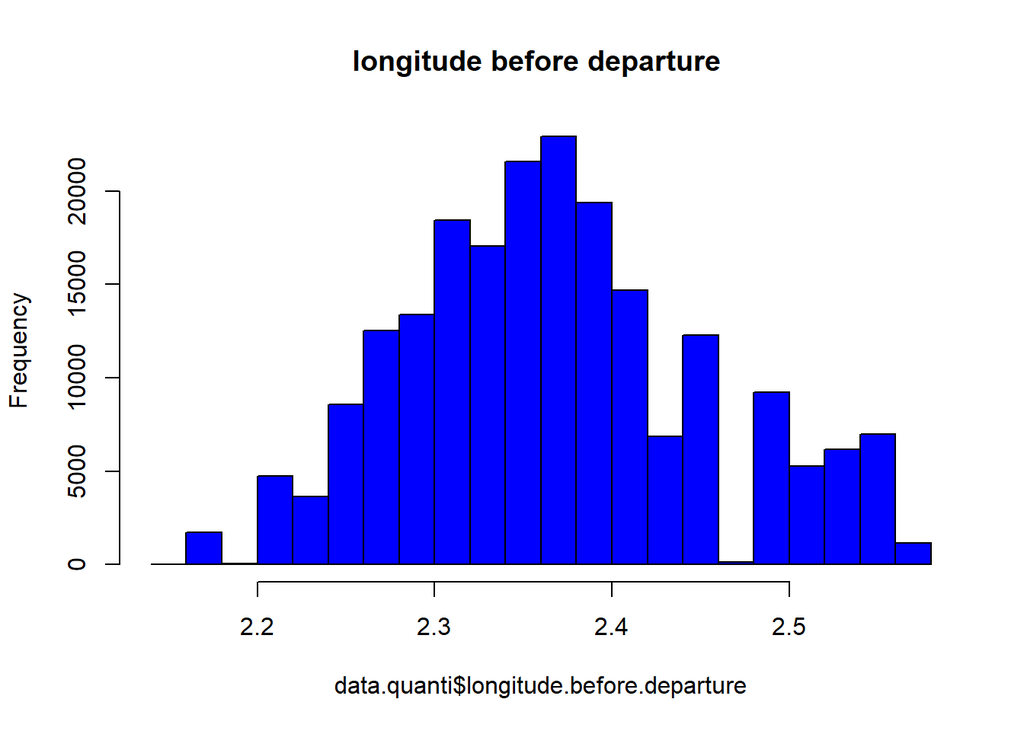

```r
hist(data.quanti$longitude.before.departure, col="blue",main="longitude before departure ")
```

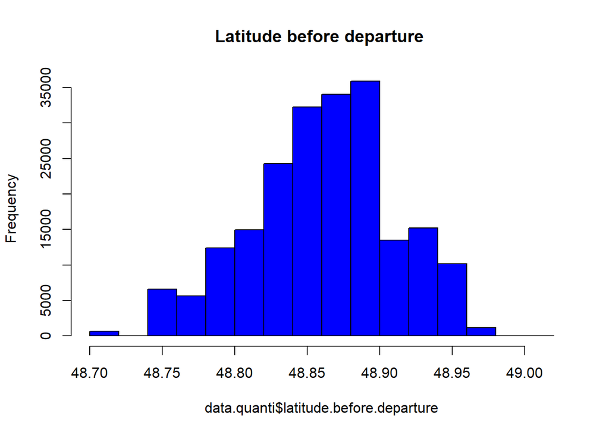

```r
hist(data.quanti$latitude.before.departure, col="blue",main="Latitude before departure ")
```

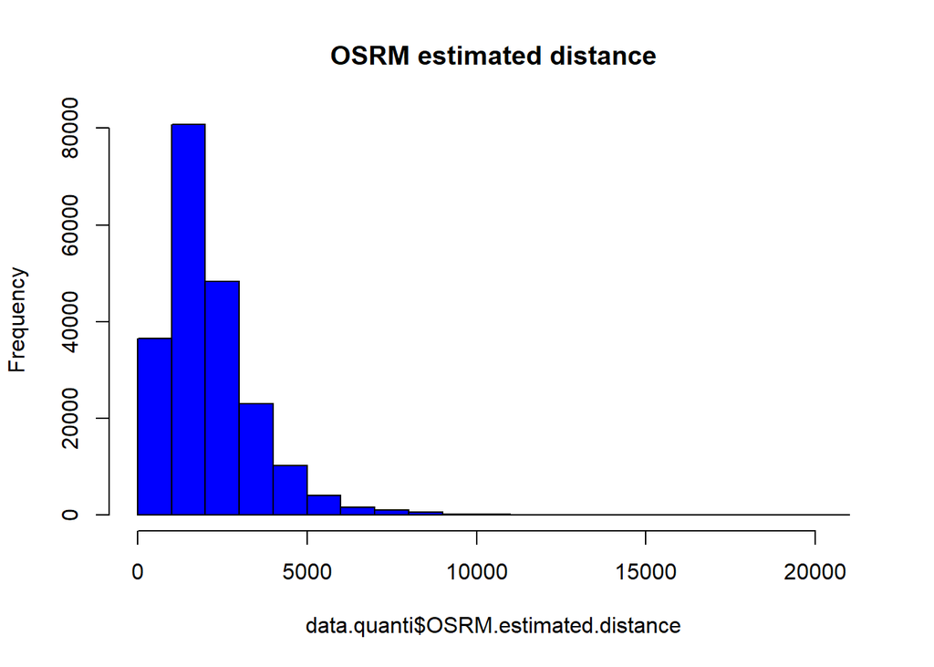

```r
hist(data.quanti$OSRM.estimated.distance, col="blue",main="OSRM estimated distance")
```

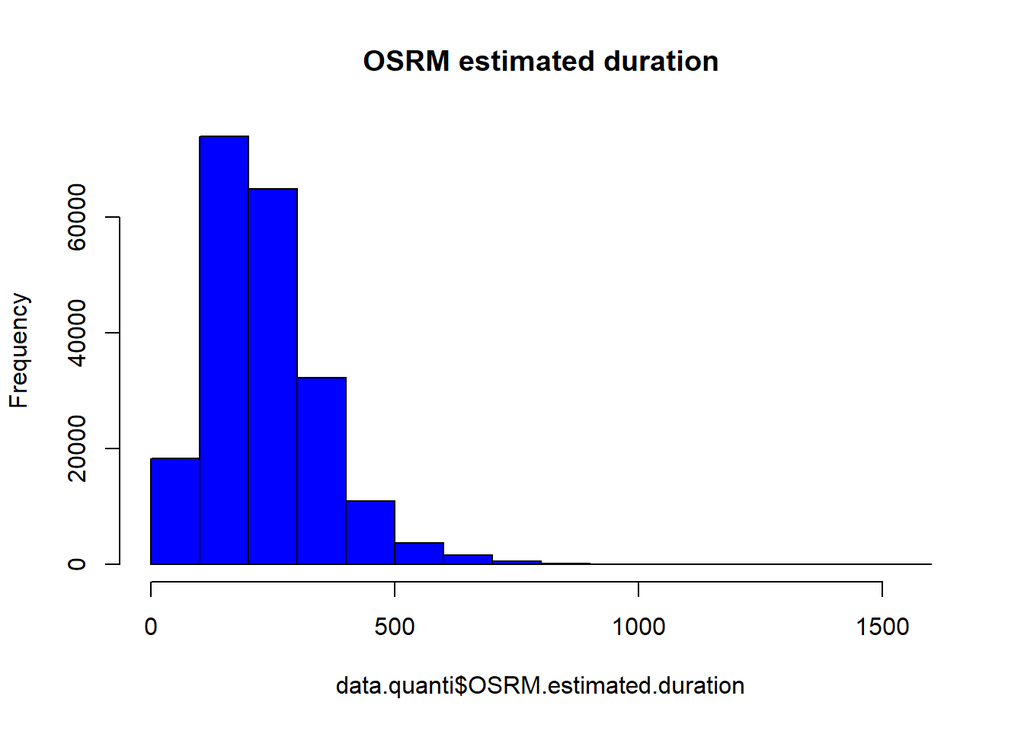

```r
hist(data.quanti$OSRM.estimated.duration, col="blue",main="OSRM estimated duration")
```

##### 3.1.1.2 Plot Variables Density Distribution

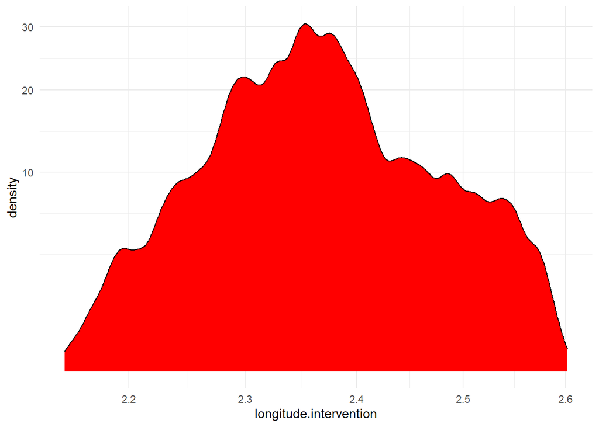

```r
data.quanti %>%
  ggplot(aes(longitude.intervention)) +
  geom_density(fill = "red", bins = 100) +
  scale_x_log10() +
  scale_y_sqrt() +
  theme_minimal()
```

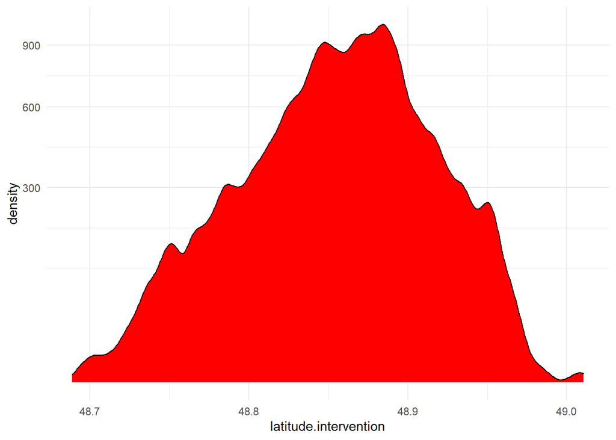

```r
data.quanti %>%
  ggplot(aes(latitude.intervention)) +
  geom_density(fill = "red", bins = 100) +
  scale_x_log10() +
  scale_y_sqrt() +
  theme_minimal()
```

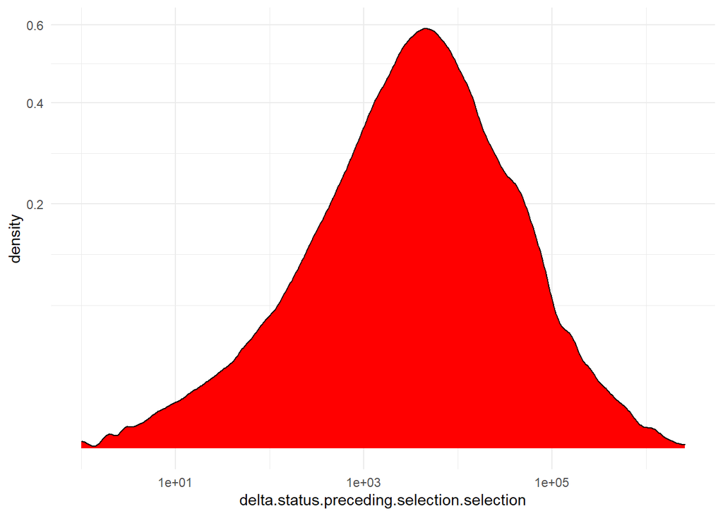

```r
data.quanti %>%
  ggplot(aes(delta.status.preceding.selection.selection)) +
  geom_density(fill = "red", bins = 100) +
  scale_x_log10() +
  scale_y_sqrt() +
  theme_minimal()
```